# Risk Factor Analysis

## Outcome Variable

**Outcome Variable:** whz

## Predictor Variables

**Intervention Variable:** exclfeed6

**Adjustment Set:**

- arm
- sex
- brthmon
- W_mage
- meducyrs
- feducyrs
- hhwealth_quart
- hfoodsec
- W_mhtcm
- W_mwtkg
- W_mbmi
- vagbrth
- W_gagebrth
- W_birthwt
- W_birthlen
- W_nrooms
- W_nchldlt5
- month
- W_parity
- impfloor
- impsan
- safeh20
- delta_W_mage
- delta_meducyrs
- delta_feducyrs
- delta_hhwealth_quart
- delta_hfoodsec
- delta_W_mhtcm
- delta_W_mwtkg
- delta_W_mbmi
- delta_vagbrth
- delta_W_gagebrth
- delta_W_birthwt
- delta_W_birthlen
- delta_W_nrooms
- delta_W_nchldlt5
- delta_month
- delta_W_parity
- delta_impfloor
- delta_impsan
- delta_safeh20

## Stratifying Variables

The analysis was stratified on these variable(s):

- agecat
- studyid
- country

## Data Summary

| agecat | studyid | country | exclfeed6 | n_cell | n |
| --- | --- | --- | --- | --- | --- |
| Birth | CMC-V-BCS-2002 | INDIA | 1 | 7 | 7 |
| Birth | CMC-V-BCS-2002 | INDIA | 0 | 0 | 7 |
| Birth | EE | PAKISTAN | 1 | 24 | 28 |
| Birth | EE | PAKISTAN | 0 | 4 | 28 |
| Birth | GMS-Nepal | NEPAL | 1 | 390 | 522 |
| Birth | GMS-Nepal | NEPAL | 0 | 132 | 522 |
| Birth | IRC | INDIA | 1 | 0 | 12 |
| Birth | IRC | INDIA | 0 | 12 | 12 |
| Birth | JiVitA-3 | BANGLADESH | 1 | 8381 | 10744 |
| Birth | JiVitA-3 | BANGLADESH | 0 | 2363 | 10744 |
| Birth | JiVitA-4 | BANGLADESH | 1 | 1799 | 2224 |
| Birth | JiVitA-4 | BANGLADESH | 0 | 425 | 2224 |
| Birth | Keneba | GAMBIA | 1 | 450 | 1327 |
| Birth | Keneba | GAMBIA | 0 | 877 | 1327 |
| Birth | MAL-ED | BANGLADESH | 1 | 29 | 194 |
| Birth | MAL-ED | BANGLADESH | 0 | 165 | 194 |
| Birth | MAL-ED | BRAZIL | 1 | 1 | 57 |
| Birth | MAL-ED | BRAZIL | 0 | 56 | 57 |
| Birth | MAL-ED | INDIA | 1 | 1 | 37 |
| Birth | MAL-ED | INDIA | 0 | 36 | 37 |
| Birth | MAL-ED | NEPAL | 1 | 2 | 23 |
| Birth | MAL-ED | NEPAL | 0 | 21 | 23 |
| Birth | MAL-ED | PERU | 1 | 2 | 208 |
| Birth | MAL-ED | PERU | 0 | 206 | 208 |
| Birth | MAL-ED | SOUTH AFRICA | 1 | 0 | 90 |
| Birth | MAL-ED | SOUTH AFRICA | 0 | 90 | 90 |
| Birth | MAL-ED | TANZANIA, UNITED REPUBLIC OF | 1 | 0 | 105 |
| Birth | MAL-ED | TANZANIA, UNITED REPUBLIC OF | 0 | 105 | 105 |
| Birth | PROVIDE | BANGLADESH | 1 | 155 | 532 |
| Birth | PROVIDE | BANGLADESH | 0 | 377 | 532 |

[output cut: 70 more lines]

The following strata were considered:

- agecat: 24 months, studyid: CMC-V-BCS-2002, country: INDIA
- agecat: 24 months, studyid: EE, country: PAKISTAN
- agecat: 24 months, studyid: GMS-Nepal, country: NEPAL
- agecat: 24 months, studyid: IRC, country: INDIA
- agecat: 24 months, studyid: JiVitA-3, country: BANGLADESH
- agecat: 24 months, studyid: JiVitA-4, country: BANGLADESH
- agecat: 24 months, studyid: Keneba, country: GAMBIA
- agecat: 24 months, studyid: LCNI-5, country: MALAWI
- agecat: 24 months, studyid: MAL-ED, country: BANGLADESH
- agecat: 24 months, studyid: MAL-ED, country: BRAZIL
- agecat: 24 months, studyid: MAL-ED, country: INDIA
- agecat: 24 months, studyid: MAL-ED, country: NEPAL
- agecat: 24 months, studyid: MAL-ED, country: PERU
- agecat: 24 months, studyid: MAL-ED, country: SOUTH AFRICA
- agecat: 24 months, studyid: MAL-ED, country: TANZANIA, UNITED REPUBLIC OF
- agecat: 24 months, studyid: PROVIDE, country: BANGLADESH
- agecat: 6 months, studyid: CMC-V-BCS-2002, country: INDIA
- agecat: 6 months, studyid: EE, country: PAKISTAN
- agecat: 6 months, studyid: GMS-Nepal, country: NEPAL
- agecat: 6 months, studyid: IRC, country: INDIA
- agecat: 6 months, studyid: JiVitA-3, country: BANGLADESH
- agecat: 6 months, studyid: JiVitA-4, country: BANGLADESH
- agecat: 6 months, studyid: Keneba, country: GAMBIA
- agecat: 6 months, studyid: LCNI-5, country: MALAWI
- agecat: 6 months, studyid: MAL-ED, country: BANGLADESH
- agecat: 6 months, studyid: MAL-ED, country: BRAZIL
- agecat: 6 months, studyid: MAL-ED, country: INDIA
- agecat: 6 months, studyid: MAL-ED, country: NEPAL
- agecat: 6 months, studyid: MAL-ED, country: PERU
- agecat: 6 months, studyid: MAL-ED, country: SOUTH AFRICA
- agecat: 6 months, studyid: MAL-ED, country: TANZANIA, UNITED REPUBLIC OF
- agecat: 6 months, studyid: PROVIDE, country: BANGLADESH
- agecat: 6 months, studyid: SAS-CompFeed, country: INDIA
- agecat: 6 months, studyid: SAS-FoodSuppl, country: INDIA
- agecat: Birth, studyid: CMC-V-BCS-2002, country: INDIA
- agecat: Birth, studyid: EE, country: PAKISTAN
- agecat: Birth, studyid: GMS-Nepal, country: NEPAL
- agecat: Birth, studyid: IRC, country: INDIA
- agecat: Birth, studyid: JiVitA-3, country: BANGLADESH
- agecat: Birth, studyid: JiVitA-4, country: BANGLADESH
- agecat: Birth, studyid: Keneba, country: GAMBIA
- agecat: Birth, studyid: MAL-ED, country: BANGLADESH
- agecat: Birth, studyid: MAL-ED, country: BRAZIL
- agecat: Birth, studyid: MAL-ED, country: INDIA
- agecat: Birth, studyid: MAL-ED, country: NEPAL
- agecat: Birth, studyid: MAL-ED, country: PERU
- agecat: Birth, studyid: MAL-ED, country: SOUTH AFRICA
- agecat: Birth, studyid: MAL-ED, country: TANZANIA, UNITED REPUBLIC OF
- agecat: Birth, studyid: PROVIDE, country: BANGLADESH
- agecat: Birth, studyid: SAS-CompFeed, country: INDIA

### Dropped Strata

Some strata were dropped due to rare outcomes:

- agecat: Birth, studyid: CMC-V-BCS-2002, country: INDIA
- agecat: Birth, studyid: EE, country: PAKISTAN
- agecat: Birth, studyid: IRC, country: INDIA
- agecat: Birth, studyid: MAL-ED, country: BRAZIL
- agecat: Birth, studyid: MAL-ED, country: INDIA
- agecat: Birth, studyid: MAL-ED, country: NEPAL
- agecat: Birth, studyid: MAL-ED, country: PERU
- agecat: Birth, studyid: MAL-ED, country: SOUTH AFRICA
- agecat: Birth, studyid: MAL-ED, country: TANZANIA, UNITED REPUBLIC OF
- agecat: 6 months, studyid: CMC-V-BCS-2002, country: INDIA
- agecat: 6 months, studyid: IRC, country: INDIA
- agecat: 6 months, studyid: MAL-ED, country: INDIA
- agecat: 6 months, studyid: MAL-ED, country: SOUTH AFRICA
- agecat: 6 months, studyid: MAL-ED, country: TANZANIA, UNITED REPUBLIC OF
- agecat: 6 months, studyid: SAS-FoodSuppl, country: INDIA
- agecat: 24 months, studyid: CMC-V-BCS-2002, country: INDIA
- agecat: 24 months, studyid: EE, country: PAKISTAN
- agecat: 24 months, studyid: IRC, country: INDIA
- agecat: 24 months, studyid: MAL-ED, country: INDIA
- agecat: 24 months, studyid: MAL-ED, country: PERU
- agecat: 24 months, studyid: MAL-ED, country: SOUTH AFRICA
- agecat: 24 months, studyid: MAL-ED, country: TANZANIA, UNITED REPUBLIC OF

## Methods Detail

We’re interested in the causal parameters $E[Y_a]$ for all values of $a \in \mathcal{A}$. These parameters represent the mean outcome if, possibly contrary to fact, we intervened to set all units to have $A=a$. Under the randomization and positivity assumptions, these are identified by the statistical parameters $\psi_a=E_W[E_{Y|A,W}(Y|A=a,W)]$. In addition, we’re interested in the mean of $Y$, $E[Y]$ under no intervention (the observed mean). We will estimate these parameters by using SuperLearner to fit the relevant likelihood factors – $E_{Y|A,W}(Y|A=a,W)$ and $p(A=a|W)$, and then updating our likelihood fit using a joint TMLE.

For unadjusted analyses ($W=\{\}$), initial likelihoods were estimated using Lrnr_glm to estimate the simple $E(Y|A)$ and Lrnr_mean to estimate $p(A)$. For adjusted analyses, a small library containing Lrnr_glmnet, Lrnr_xgboost, and Lrnr_mean was used.

# Results Detail

## Results Plots

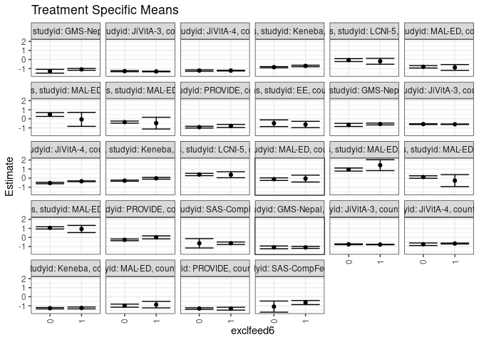

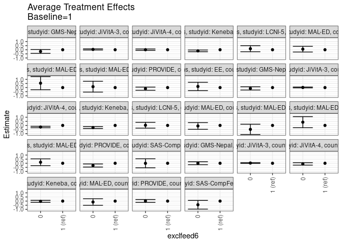

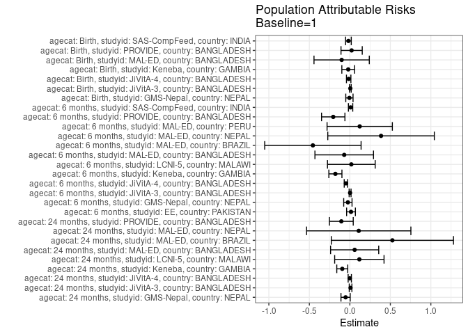

## Results Table

### Parameter: TSM

| agecat | studyid | country | intervention_level | baseline_level | estimate | ci_lower | ci_upper |
| --- | --- | --- | --- | --- | --- | --- | --- |
| Birth | GMS-Nepal | NEPAL | 1 | NA | -1.1009322 | -1.2127290 | -0.9891354 |
| Birth | GMS-Nepal | NEPAL | 0 | NA | -1.0985175 | -1.2526372 | -0.9443977 |
| Birth | JiVitA-3 | BANGLADESH | 1 | NA | -0.7866578 | -0.8115159 | -0.7617996 |
| Birth | JiVitA-3 | BANGLADESH | 0 | NA | -0.7599346 | -0.8034641 | -0.7164050 |
| Birth | JiVitA-4 | BANGLADESH | 1 | NA | -0.6758381 | -0.7308245 | -0.6208517 |
| Birth | JiVitA-4 | BANGLADESH | 0 | NA | -0.7530802 | -0.8914987 | -0.6146617 |
| Birth | Keneba | GAMBIA | 1 | NA | -1.2399228 | -1.3422788 | -1.1375669 |
| Birth | Keneba | GAMBIA | 0 | NA | -1.2675270 | -1.3440926 | -1.1909613 |
| Birth | MAL-ED | BANGLADESH | 1 | NA | -0.8741949 | -1.2313066 | -0.5170832 |
| Birth | MAL-ED | BANGLADESH | 0 | NA | -0.9871787 | -1.1570831 | -0.8172742 |
| Birth | PROVIDE | BANGLADESH | 1 | NA | -1.3201512 | -1.4769958 | -1.1633066 |
| Birth | PROVIDE | BANGLADESH | 0 | NA | -1.3056656 | -1.3939795 | -1.2173517 |
| Birth | SAS-CompFeed | INDIA | 1 | NA | -0.6419787 | -0.8661092 | -0.4178481 |
| Birth | SAS-CompFeed | INDIA | 0 | NA | -1.0901281 | -1.7027393 | -0.4775170 |
| 6 months | EE | PAKISTAN | 1 | NA | -0.6248062 | -0.9715960 | -0.2780164 |
| 6 months | EE | PAKISTAN | 0 | NA | -0.4893333 | -0.8590751 | -0.1195916 |
| 6 months | GMS-Nepal | NEPAL | 1 | NA | -0.5764001 | -0.6787691 | -0.4740311 |
| 6 months | GMS-Nepal | NEPAL | 0 | NA | -0.6751264 | -0.8466486 | -0.5036042 |
| 6 months | JiVitA-3 | BANGLADESH | 1 | NA | -0.6030123 | -0.6301368 | -0.5758878 |
| 6 months | JiVitA-3 | BANGLADESH | 0 | NA | -0.5899838 | -0.6353071 | -0.5446606 |
| 6 months | JiVitA-4 | BANGLADESH | 1 | NA | -0.3485079 | -0.3932835 | -0.3037322 |
| 6 months | JiVitA-4 | BANGLADESH | 0 | NA | -0.5461468 | -0.6246049 | -0.4676887 |
| 6 months | Keneba | GAMBIA | 1 | NA | -0.0211289 | -0.1190955 | 0.0768378 |
| 6 months | Keneba | GAMBIA | 0 | NA | -0.2812117 | -0.3436647 | -0.2187587 |
| 6 months | LCNI-5 | MALAWI | 1 | NA | 0.3742723 | 0.0428781 | 0.7056666 |
| 6 months | LCNI-5 | MALAWI | 0 | NA | 0.3977762 | 0.2710039 | 0.5245486 |
| 6 months | MAL-ED | BANGLADESH | 1 | NA | -0.0516853 | -0.4309940 | 0.3276234 |
| 6 months | MAL-ED | BANGLADESH | 0 | NA | -0.1174775 | -0.2627470 | 0.0277920 |
| 6 months | MAL-ED | BRAZIL | 1 | NA | 1.4284076 | 0.8240996 | 2.0327156 |
| 6 months | MAL-ED | BRAZIL | 0 | NA | 0.9460318 | 0.7762006 | 1.1158631 |
| 6 months | MAL-ED | NEPAL | 1 | NA | -0.2760000 | -0.9362767 | 0.3842767 |
| 6 months | MAL-ED | NEPAL | 0 | NA | 0.1178939 | -0.0200258 | 0.2558137 |
| 6 months | MAL-ED | PERU | 1 | NA | 0.9290000 | 0.5350705 | 1.3229295 |
| 6 months | MAL-ED | PERU | 0 | NA | 1.0529010 | 0.9277571 | 1.1780449 |
| 6 months | PROVIDE | BANGLADESH | 1 | NA | 0.0060787 | -0.1572572 | 0.1694145 |
| 6 months | PROVIDE | BANGLADESH | 0 | NA | -0.2667018 | -0.3613924 | -0.1720112 |
| 6 months | SAS-CompFeed | INDIA | 1 | NA | -0.6438016 | -0.7819173 | -0.5056859 |
| 6 months | SAS-CompFeed | INDIA | 0 | NA | -0.6500492 | -1.1672739 | -0.1328245 |
| 24 months | GMS-Nepal | NEPAL | 1 | NA | -1.0896264 | -1.1896343 | -0.9896184 |
| 24 months | GMS-Nepal | NEPAL | 0 | NA | -1.2966091 | -1.5061373 | -1.0870810 |
| 24 months | JiVitA-3 | BANGLADESH | 1 | NA | -1.3191918 | -1.3541013 | -1.2842824 |
| 24 months | JiVitA-3 | BANGLADESH | 0 | NA | -1.2822974 | -1.3449003 | -1.2196946 |
| 24 months | JiVitA-4 | BANGLADESH | 1 | NA | -1.2255585 | -1.2673018 | -1.1838152 |
| 24 months | JiVitA-4 | BANGLADESH | 0 | NA | -1.2217597 | -1.3029781 | -1.1405413 |
| 24 months | Keneba | GAMBIA | 1 | NA | -0.7095482 | -0.7926393 | -0.6264572 |
| 24 months | Keneba | GAMBIA | 0 | NA | -0.8474135 | -0.9088172 | -0.7860098 |
| 24 months | LCNI-5 | MALAWI | 1 | NA | -0.1942986 | -0.5224672 | 0.1338699 |
| 24 months | LCNI-5 | MALAWI | 0 | NA | -0.0673385 | -0.2289523 | 0.0942752 |
| 24 months | MAL-ED | BANGLADESH | 1 | NA | -0.8762017 | -1.1927636 | -0.5596397 |
| 24 months | MAL-ED | BANGLADESH | 0 | NA | -0.8054987 | -0.9402191 | -0.6707783 |
| 24 months | MAL-ED | BRAZIL | 1 | NA | -0.0624299 | -0.8334269 | 0.7085672 |
| 24 months | MAL-ED | BRAZIL | 0 | NA | 0.4745478 | 0.2594619 | 0.6896337 |
| 24 months | MAL-ED | NEPAL | 1 | NA | -0.4770000 | -1.1267115 | 0.1727115 |
| 24 months | MAL-ED | NEPAL | 0 | NA | -0.3648832 | -0.4833183 | -0.2464480 |
| 24 months | PROVIDE | BANGLADESH | 1 | NA | -0.7877038 | -0.9546143 | -0.6207933 |
| 24 months | PROVIDE | BANGLADESH | 0 | NA | -0.9220894 | -1.0170292 | -0.8271495 |

### Parameter: E(Y)

| agecat | studyid | country | intervention_level | baseline_level | estimate | ci_lower | ci_upper |
| --- | --- | --- | --- | --- | --- | --- | --- |
| Birth | GMS-Nepal | NEPAL | NA | NA | -1.1064559 | -1.2034951 | -1.0094168 |
| Birth | JiVitA-3 | BANGLADESH | NA | NA | -0.7807809 | -0.8030521 | -0.7585097 |
| Birth | JiVitA-4 | BANGLADESH | NA | NA | -0.6904586 | -0.7435822 | -0.6373351 |
| Birth | Keneba | GAMBIA | NA | NA | -1.2599925 | -1.3251703 | -1.1948146 |
| Birth | MAL-ED | BANGLADESH | NA | NA | -0.9755670 | -1.1287016 | -0.8224325 |
| Birth | PROVIDE | BANGLADESH | NA | NA | -1.2984586 | -1.3752758 | -1.2216415 |
| Birth | SAS-CompFeed | INDIA | NA | NA | -0.6596308 | -0.9005716 | -0.4186900 |
| 6 months | EE | PAKISTAN | NA | NA | -0.6106944 | -0.9239621 | -0.2974268 |
| 6 months | GMS-Nepal | NEPAL | NA | NA | -0.6009171 | -0.6886356 | -0.5131986 |
| 6 months | JiVitA-3 | BANGLADESH | NA | NA | -0.6001300 | -0.6240378 | -0.5762223 |
| 6 months | JiVitA-4 | BANGLADESH | NA | NA | -0.3968456 | -0.4358721 | -0.3578192 |
| 6 months | Keneba | GAMBIA | NA | NA | -0.1997647 | -0.2531388 | -0.1463906 |
| 6 months | LCNI-5 | MALAWI | NA | NA | 0.3925000 | 0.2735307 | 0.5114693 |
| 6 months | MAL-ED | BANGLADESH | NA | NA | -0.1213203 | -0.2539388 | 0.0112981 |
| 6 months | MAL-ED | BRAZIL | NA | NA | 0.9720774 | 0.8078144 | 1.1363403 |
| 6 months | MAL-ED | NEPAL | NA | NA | 0.1091407 | -0.0265536 | 0.2448351 |
| 6 months | MAL-ED | PERU | NA | NA | 1.0506150 | 0.9281868 | 1.1730433 |
| 6 months | PROVIDE | BANGLADESH | NA | NA | -0.1990907 | -0.2817968 | -0.1163845 |
| 6 months | SAS-CompFeed | INDIA | NA | NA | -0.6348861 | -0.7630511 | -0.5067211 |
| 24 months | GMS-Nepal | NEPAL | NA | NA | -1.1423525 | -1.2336321 | -1.0510729 |
| 24 months | JiVitA-3 | BANGLADESH | NA | NA | -1.3103375 | -1.3408810 | -1.2797940 |
| 24 months | JiVitA-4 | BANGLADESH | NA | NA | -1.2265320 | -1.2620508 | -1.1910132 |
| 24 months | Keneba | GAMBIA | NA | NA | -0.8032329 | -0.8532842 | -0.7531817 |
| 24 months | LCNI-5 | MALAWI | NA | NA | -0.0770652 | -0.2204213 | 0.0662909 |
| 24 months | MAL-ED | BANGLADESH | NA | NA | -0.8169756 | -0.9388013 | -0.6951499 |
| 24 months | MAL-ED | BRAZIL | NA | NA | 0.4626233 | 0.2567495 | 0.6684971 |
| 24 months | MAL-ED | NEPAL | NA | NA | -0.3674429 | -0.4840752 | -0.2508107 |
| 24 months | PROVIDE | BANGLADESH | NA | NA | -0.8928670 | -0.9755153 | -0.8102187 |

### Parameter: ATE

| agecat | studyid | country | intervention_level | baseline_level | estimate | ci_lower | ci_upper |
| --- | --- | --- | --- | --- | --- | --- | --- |
| Birth | GMS-Nepal | NEPAL | 1 | 1 | 0.0000000 | 0.0000000 | 0.0000000 |
| Birth | GMS-Nepal | NEPAL | 0 | 1 | 0.0024147 | -0.1746681 | 0.1794976 |
| Birth | JiVitA-3 | BANGLADESH | 1 | 1 | 0.0000000 | 0.0000000 | 0.0000000 |
| Birth | JiVitA-3 | BANGLADESH | 0 | 1 | 0.0267232 | -0.0216554 | 0.0751017 |
| Birth | JiVitA-4 | BANGLADESH | 1 | 1 | 0.0000000 | 0.0000000 | 0.0000000 |
| Birth | JiVitA-4 | BANGLADESH | 0 | 1 | -0.0772421 | -0.2224528 | 0.0679686 |
| Birth | Keneba | GAMBIA | 1 | 1 | 0.0000000 | 0.0000000 | 0.0000000 |
| Birth | Keneba | GAMBIA | 0 | 1 | -0.0276042 | -0.1454154 | 0.0902071 |
| Birth | MAL-ED | BANGLADESH | 1 | 1 | 0.0000000 | 0.0000000 | 0.0000000 |
| Birth | MAL-ED | BANGLADESH | 0 | 1 | -0.1129838 | -0.5121264 | 0.2861588 |
| Birth | PROVIDE | BANGLADESH | 1 | 1 | 0.0000000 | 0.0000000 | 0.0000000 |
| Birth | PROVIDE | BANGLADESH | 0 | 1 | 0.0144856 | -0.1603199 | 0.1892910 |
| Birth | SAS-CompFeed | INDIA | 1 | 1 | 0.0000000 | 0.0000000 | 0.0000000 |
| Birth | SAS-CompFeed | INDIA | 0 | 1 | -0.4481495 | -0.9783681 | 0.0820692 |
| 6 months | EE | PAKISTAN | 1 | 1 | 0.0000000 | 0.0000000 | 0.0000000 |
| 6 months | EE | PAKISTAN | 0 | 1 | 0.1354729 | -0.3714513 | 0.6423970 |
| 6 months | GMS-Nepal | NEPAL | 1 | 1 | 0.0000000 | 0.0000000 | 0.0000000 |
| 6 months | GMS-Nepal | NEPAL | 0 | 1 | -0.0987263 | -0.2986906 | 0.1012380 |
| 6 months | JiVitA-3 | BANGLADESH | 1 | 1 | 0.0000000 | 0.0000000 | 0.0000000 |
| 6 months | JiVitA-3 | BANGLADESH | 0 | 1 | 0.0130285 | -0.0383818 | 0.0644387 |
| 6 months | JiVitA-4 | BANGLADESH | 1 | 1 | 0.0000000 | 0.0000000 | 0.0000000 |
| 6 months | JiVitA-4 | BANGLADESH | 0 | 1 | -0.1976389 | -0.2877218 | -0.1075561 |
| 6 months | Keneba | GAMBIA | 1 | 1 | 0.0000000 | 0.0000000 | 0.0000000 |
| 6 months | Keneba | GAMBIA | 0 | 1 | -0.2600828 | -0.3755530 | -0.1446126 |
| 6 months | LCNI-5 | MALAWI | 1 | 1 | 0.0000000 | 0.0000000 | 0.0000000 |
| 6 months | LCNI-5 | MALAWI | 0 | 1 | 0.0235039 | -0.3315429 | 0.3785507 |
| 6 months | MAL-ED | BANGLADESH | 1 | 1 | 0.0000000 | 0.0000000 | 0.0000000 |
| 6 months | MAL-ED | BANGLADESH | 0 | 1 | -0.0657922 | -0.4724237 | 0.3408393 |
| 6 months | MAL-ED | BRAZIL | 1 | 1 | 0.0000000 | 0.0000000 | 0.0000000 |
| 6 months | MAL-ED | BRAZIL | 0 | 1 | -0.4823757 | -1.1091535 | 0.1444021 |
| 6 months | MAL-ED | NEPAL | 1 | 1 | 0.0000000 | 0.0000000 | 0.0000000 |
| 6 months | MAL-ED | NEPAL | 0 | 1 | 0.3938939 | -0.2806334 | 1.0684213 |
| 6 months | MAL-ED | PERU | 1 | 1 | 0.0000000 | 0.0000000 | 0.0000000 |
| 6 months | MAL-ED | PERU | 0 | 1 | 0.1239010 | -0.2894287 | 0.5372307 |
| 6 months | PROVIDE | BANGLADESH | 1 | 1 | 0.0000000 | 0.0000000 | 0.0000000 |
| 6 months | PROVIDE | BANGLADESH | 0 | 1 | -0.2727805 | -0.4605196 | -0.0850413 |
| 6 months | SAS-CompFeed | INDIA | 1 | 1 | 0.0000000 | 0.0000000 | 0.0000000 |
| 6 months | SAS-CompFeed | INDIA | 0 | 1 | -0.0062476 | -0.5560776 | 0.5435824 |
| 24 months | GMS-Nepal | NEPAL | 1 | 1 | 0.0000000 | 0.0000000 | 0.0000000 |
| 24 months | GMS-Nepal | NEPAL | 0 | 1 | -0.2069828 | -0.4394682 | 0.0255026 |
| 24 months | JiVitA-3 | BANGLADESH | 1 | 1 | 0.0000000 | 0.0000000 | 0.0000000 |
| 24 months | JiVitA-3 | BANGLADESH | 0 | 1 | 0.0368944 | -0.0344757 | 0.1082645 |
| 24 months | JiVitA-4 | BANGLADESH | 1 | 1 | 0.0000000 | 0.0000000 | 0.0000000 |
| 24 months | JiVitA-4 | BANGLADESH | 0 | 1 | 0.0037988 | -0.0857596 | 0.0933572 |
| 24 months | Keneba | GAMBIA | 1 | 1 | 0.0000000 | 0.0000000 | 0.0000000 |
| 24 months | Keneba | GAMBIA | 0 | 1 | -0.1378653 | -0.2398458 | -0.0358848 |
| 24 months | LCNI-5 | MALAWI | 1 | 1 | 0.0000000 | 0.0000000 | 0.0000000 |
| 24 months | LCNI-5 | MALAWI | 0 | 1 | 0.1269601 | -0.2414133 | 0.4953335 |
| 24 months | MAL-ED | BANGLADESH | 1 | 1 | 0.0000000 | 0.0000000 | 0.0000000 |
| 24 months | MAL-ED | BANGLADESH | 0 | 1 | 0.0707029 | -0.2776292 | 0.4190350 |
| 24 months | MAL-ED | BRAZIL | 1 | 1 | 0.0000000 | 0.0000000 | 0.0000000 |
| 24 months | MAL-ED | BRAZIL | 0 | 1 | 0.5369777 | -0.2628120 | 1.3367673 |
| 24 months | MAL-ED | NEPAL | 1 | 1 | 0.0000000 | 0.0000000 | 0.0000000 |
| 24 months | MAL-ED | NEPAL | 0 | 1 | 0.1121168 | -0.5483011 | 0.7725348 |
| 24 months | PROVIDE | BANGLADESH | 1 | 1 | 0.0000000 | 0.0000000 | 0.0000000 |
| 24 months | PROVIDE | BANGLADESH | 0 | 1 | -0.1343856 | -0.3263807 | 0.0576096 |

### Parameter: PAR

| agecat | studyid | country | intervention_level | baseline_level | estimate | ci_lower | ci_upper |
| --- | --- | --- | --- | --- | --- | --- | --- |
| Birth | GMS-Nepal | NEPAL | 1 | NA | -0.0055237 | -0.0503345 | 0.0392870 |
| Birth | JiVitA-3 | BANGLADESH | 1 | NA | 0.0058769 | -0.0047590 | 0.0165127 |
| Birth | JiVitA-4 | BANGLADESH | 1 | NA | -0.0146205 | -0.0420306 | 0.0127896 |
| Birth | Keneba | GAMBIA | 1 | NA | -0.0200696 | -0.0990066 | 0.0588673 |
| Birth | MAL-ED | BANGLADESH | 1 | NA | -0.1013721 | -0.4427260 | 0.2399818 |
| Birth | PROVIDE | BANGLADESH | 1 | NA | 0.0216926 | -0.1093506 | 0.1527357 |
| Birth | SAS-CompFeed | INDIA | 1 | NA | -0.0176521 | -0.0527130 | 0.0174088 |
| 6 months | EE | PAKISTAN | 1 | NA | 0.0141118 | -0.0400020 | 0.0682256 |
| 6 months | GMS-Nepal | NEPAL | 1 | NA | -0.0245171 | -0.0759305 | 0.0268964 |
| 6 months | JiVitA-3 | BANGLADESH | 1 | NA | 0.0028823 | -0.0089260 | 0.0146906 |
| 6 months | JiVitA-4 | BANGLADESH | 1 | NA | -0.0483378 | -0.0695895 | -0.0270860 |
| 6 months | Keneba | GAMBIA | 1 | NA | -0.1786358 | -0.2594462 | -0.0978253 |
| 6 months | LCNI-5 | MALAWI | 1 | NA | 0.0182277 | -0.2762280 | 0.3126833 |
| 6 months | MAL-ED | BANGLADESH | 1 | NA | -0.0696350 | -0.4311379 | 0.2918678 |
| 6 months | MAL-ED | BRAZIL | 1 | NA | -0.4563302 | -1.0513079 | 0.1386475 |
| 6 months | MAL-ED | NEPAL | 1 | NA | 0.3851407 | -0.2725674 | 1.0428489 |
| 6 months | MAL-ED | PERU | 1 | NA | 0.1216150 | -0.2813864 | 0.5246164 |
| 6 months | PROVIDE | BANGLADESH | 1 | NA | -0.2051693 | -0.3495156 | -0.0608231 |
| 6 months | SAS-CompFeed | INDIA | 1 | NA | 0.0089155 | -0.0178262 | 0.0356572 |
| 24 months | GMS-Nepal | NEPAL | 1 | NA | -0.0527262 | -0.1097246 | 0.0042723 |
| 24 months | JiVitA-3 | BANGLADESH | 1 | NA | 0.0088544 | -0.0075205 | 0.0252292 |
| 24 months | JiVitA-4 | BANGLADESH | 1 | NA | -0.0009735 | -0.0210394 | 0.0190923 |
| 24 months | Keneba | GAMBIA | 1 | NA | -0.0936847 | -0.1614842 | -0.0258852 |
| 24 months | LCNI-5 | MALAWI | 1 | NA | 0.1172334 | -0.1875106 | 0.4219775 |
| 24 months | MAL-ED | BANGLADESH | 1 | NA | 0.0592261 | -0.2379794 | 0.3564315 |
| 24 months | MAL-ED | BRAZIL | 1 | NA | 0.5250532 | -0.2291766 | 1.2792830 |
| 24 months | MAL-ED | NEPAL | 1 | NA | 0.1095571 | -0.5343543 | 0.7534684 |
| 24 months | PROVIDE | BANGLADESH | 1 | NA | -0.1051632 | -0.2520082 | 0.0416818 |